# Data exploration: first sight

```r
library(tidyverse)
```

In this file I am going to enact a first exploration of the data I have.

I will start reading the ‘.csv’ files and using a few useful functions like ‘glimpse’ to familiarise with them.

```r
airlines <- read_csv(here::here("raw_data/airlines.csv"))
airports <- read_csv(here::here("raw_data/airports.csv"))
flights <- read_csv(here::here("raw_data/flights.csv"))
planes <- read_csv(here::here("raw_data/planes.csv"))
weather <- read_csv(here::here("raw_data/weather.csv"))
```

# `airlines`

```r
glimpse(airlines)
```

```
Rows: 12
Columns: 2
$ carrier <chr> "AA", "AS", "B6", "DL", "EV", "F9", "HA", "NK", "OO", "UA", "VX", "WN"
$ name    <chr> "American Airlines Inc.", "Alaska Airlines Inc.", "JetBlue Airways", "Delta Air Lines Inc.", "ExpressJet Air…
```

| carrier |
| --- |
| AA |
| AS |
| B6 |
| DL |
| EV |
| F9 |
| HA |
| NK |
| OO |
| UA |

[output cut: 2 more lines]

| name |
| --- |
| American Airlines Inc. |
| Alaska Airlines Inc. |
| JetBlue Airways |
| Delta Air Lines Inc. |
| ExpressJet Airlines Inc. |
| Frontier Airlines Inc. |
| Hawaiian Airlines Inc. |
| Spirit Air Lines |
| SkyWest Airlines Inc. |
| United Air Lines Inc. |

[output cut: 2 more lines]

## `airlines` NAs

| carrier | name |
| --- | --- |
| 0 | 0 |

No NAs!!!

# `airports`

```r
glimpse(airports)
```

```
Rows: 1,333
Columns: 8
$ faa   <chr> "0V4", "19S", "23M", "2A5", "2H0", "2K7", "3AU", "4A7", "4U9", "52A", "57C", "5B2", "6J4", "6S0", "7W6", "87K…
$ name  <chr> "Brookneal/Campbell County Airport", "Sublette Municipal Airport", "Clarke County Airport", "Causey Airport",…
$ lat   <dbl> 37.14170, 37.49140, 32.08490, 35.91180, 39.41040, 37.43540, 37.67160, 33.38910, 44.73570, 33.61210, 42.79720,…
$ lon   <dbl> -79.01640, -100.83000, -88.73890, -79.61760, -88.84540, -95.64610, -97.07790, -84.33240, -112.72000, -83.4604…
$ alt   <dbl> 596, 2908, 320, 723, 618, 841, 1328, 874, 6007, 694, 860, 434, 555, 4492, 8, 931, 1300, 6145, 20, 79, 393, 17…
$ tz    <dbl> -5, -5, -6, -5, -6, -5, -5, -5, -7, -5, -6, -5, -5, -7, -5, -5, -7, -7, -5, -6, -5, -6, -9, -7, -6, -5, -5, -…
$ dst   <chr> "A", "A", "A", "A", "A", "A", "A", "A", "A", "A", "A", "A", "A", "A", "A", "A", "A", "A", "A", "A", "A", "A",…
$ tzone <chr> "America/New_York", NA, "America/Chicago", "America/New_York", "America/Chicago", NA, NA, "America/New_York",…
```

| tzone |
| --- |
| America/New_York |
| NA |
| America/Chicago |
| America/Denver |
| America/Phoenix |
| America/Anchorage |
| America/Los_Angeles |
| America/Adak |
| Pacific/Honolulu |
| Australia/Sydney |

[output cut: 1 more lines]

11 different ‘time zones’ are considered in the dataset.

| tz |
| --- |
| -5 |
| -6 |
| -7 |
| -9 |
| -8 |
| -10 |
| NA |
| -4 |
| 10 |
| 8 |

[output cut: 1 more lines]

| dst |
| --- |
| A |
| NA |
| U |
| N |
| E |

| faa | name | lat | lon | alt | tz | dst | tzone |
| --- | --- | --- | --- | --- | --- | --- | --- |
| BUF | Buffalo Niagara International Airport | 42.9405 | -78.7322 | 728 | -5 | A | America/New_York |
| JFK | John F Kennedy International Airport | 40.6398 | -73.7789 | 13 | -5 | A | America/New_York |
| MIA | Miami International Airport | 25.7932 | -80.2906 | 8 | -5 | A | America/New_York |

## `airports` NAs

| faa | name | lat | lon | alt | tz | dst | tzone |
| --- | --- | --- | --- | --- | --- | --- | --- |
| 0 | 0 | 0 | 0 | 0 | 56 | 56 | 134 |

There are Nas in the columns: `tz`, `dst` and `tzone`!

Let’s investigate a bit the relationship between `tz` and `tzone`.

```r
airports %>%
  group_by(tzone, tz) %>%
  summarise(num = n()) %>%
  arrange(desc(tz))
```

| tzone | tz | num |
| --- | --- | --- |
| Australia/Sydney | 10 | 1 |
| NA | 8 | 1 |
| Europe/Budapest | 1 | 1 |
| NA | -4 | 8 |
| America/New_York | -5 | 412 |
| NA | -5 | 55 |
| America/Chicago | -6 | 306 |
| NA | -6 | 3 |
| America/Denver | -7 | 114 |
| America/Phoenix | -7 | 32 |

[output cut: 7 more lines]

There are 56 airports of which we don’t know neither the time zone, nor the time zone offset from GMT. For all the other airports if we don’t know the exact timezone, we at least know their time zone offset from GMT. I will decide later how to deal with these NAs.

# `flights`

```r
glimpse(flights)
```

```
Rows: 303,748
Columns: 19
$ year           <dbl> 2017, 2017, 2017, 2017, 2017, 2017, 2017, 2017, 2017, 2017, 2017, 2017, 2017, 2017, 2017, 2017, 2017…
$ month          <dbl> 10, 10, 10, 10, 10, 10, 10, 10, 10, 10, 10, 10, 10, 10, 10, 10, 10, 10, 10, 10, 10, 10, 10, 10, 10, …
$ day            <dbl> 1, 1, 1, 1, 1, 1, 1, 1, 1, 1, 1, 1, 1, 1, 1, 1, 1, 1, 1, 1, 1, 1, 1, 1, 1, 1, 1, 1, 1, 1, 1, 1, 1, 1…
$ dep_time       <dbl> 27, 519, 544, 546, 552, 553, 554, 555, 555, 556, 556, 556, 556, 556, 556, 557, 557, 606, 607, 607, 6…
$ sched_dep_time <dbl> 2114, 525, 545, 550, 600, 600, 600, 607, 600, 600, 600, 600, 600, 600, 600, 600, 606, 610, 615, 615,…
$ dep_delay      <dbl> 193, -6, -1, -4, -8, -7, -6, -12, -5, -4, -4, -4, -4, -4, -4, -3, -9, -4, -8, -8, 733, -8, -7, -7, -…
$ arr_time       <dbl> 317, 741, 815, 702, 846, 852, 844, 831, 841, 802, 759, 653, 649, 854, 835, 850, 706, 813, 827, 747, …
$ sched_arr_time <dbl> 15, 759, 819, 719, 850, 858, 844, 853, 902, 815, 820, 720, 725, 854, 844, 902, 722, 840, 844, 809, 2…
$ arr_delay      <dbl> 182, -18, -4, -17, -4, -6, 0, -22, -21, -13, -21, -27, -36, 0, -9, -12, -16, -27, -17, -22, 708, -7,…
$ carrier        <chr> "UA", "UA", "B6", "UA", "NK", "B6", "AA", "UA", "AA", "DL", "DL", "WN", "WN", "B6", "B6", "AA", "B6"…
$ flight         <dbl> 1537, 1161, 27, 761, 521, 23, 129, 1465, 1301, 575, 1447, 884, 1161, 371, 583, 1399, 2802, 435, 1115…
$ tailnum        <chr> "N54711", "N37287", "N547JB", "N38446", "N675NK", "N967JB", "N3GMAA", "N17229", "N3BMAA", "N932DL", …
$ origin         <chr> "EWR", "EWR", "EWR", "LGA", "EWR", "JFK", "LGA", "EWR", "EWR", "EWR", "LGA", "EWR", "LGA", "LGA", "J…
$ dest           <chr> "MIA", "IAH", "MCO", "ORD", "FLL", "LAX", "MCO", "DFW", "MIA", "ATL", "ATL", "MDW", "MDW", "FLL", "M…
$ air_time       <dbl> 148, 183, 133, 108, 156, 326, 139, 187, 143, 103, 106, 99, 101, 156, 139, 148, 53, 105, 303, 80, 190…
$ distance       <dbl> 1085, 1400, 937, 733, 1065, 2475, 950, 1372, 1085, 746, 762, 711, 725, 1076, 944, 1096, 301, 760, 22…
$ hour           <dbl> 21, 5, 5, 5, 6, 6, 6, 6, 6, 6, 6, 6, 6, 6, 6, 6, 6, 6, 6, 6, 17, 6, 6, 6, 6, 6, 6, 6, 6, 6, 6, 6, 6,…
$ minute         <dbl> 14, 25, 45, 50, 0, 0, 0, 7, 0, 0, 0, 0, 0, 0, 0, 0, 6, 10, 15, 15, 59, 20, 25, 25, 28, 29, 29, 30, 2…
$ time_hour      <dttm> 2017-10-01 21:00:00, 2017-10-01 05:00:00, 2017-10-01 05:00:00, 2017-10-01 05:00:00, 2017-10-01 06:0…
```

| carrier |
| --- |
| UA |
| B6 |
| NK |
| AA |
| DL |
| WN |
| EV |
| AS |
| OO |
| VX |

[output cut: 2 more lines]

12 different carriers, exactly as we had in the `airlines` dataset.

| origin |
| --- |
| EWR |
| LGA |
| JFK |

| dest |
| --- |
| MIA |
| IAH |
| MCO |
| ORD |
| FLL |
| LAX |
| DFW |
| ATL |
| MDW |
| BUF |

[output cut: 99 more lines]

## `flights` NAs

| year | month | day | dep_time | sched_dep_time | dep_delay | arr_time | sched_arr_time | arr_delay | carrier | flight | tailnum | origin | dest | air_time | distance | hour | minute | time_hour |
| --- | --- | --- | --- | --- | --- | --- | --- | --- | --- | --- | --- | --- | --- | --- | --- | --- | --- | --- |
| 0 | 0 | 0 | 7810 | 0 | 7814 | 8148 | 0 | 8852 | 0 | 0 | 991 | 0 | 0 | 8852 | 0 | 0 | 0 | 0 |

There are NAs in the columns: `dap_time`, `dep_delay`, `arr_time`, `arr_delay`, `tailnum` and `air_time`!

# `planes`

```r
glimpse(planes)
```

```
Rows: 3,521
Columns: 9
$ tailnum      <chr> "N102AA", "N103AA", "N103SY", "N10575", "N105AA", "N105SY", "N106SY", "N107SY", "N108AA", "N108SY", "N…
$ year         <dbl> 2007, 2007, 2014, 2002, 1978, 2014, 2014, 2014, 1977, 2014, 2007, 2014, 2007, 2014, 2002, 2002, 2004, …
$ type         <chr> "Fixed wing single engine", "Fixed wing single engine", "Fixed wing multi engine", "Fixed wing multi e…
$ manufacturer <chr> "AVIAT AIRCRAFT INC", "AVIAT AIRCRAFT INC", "EMBRAER S A", "EMBRAER", "CESSNA", "EMBRAER S A", "EMBRAE…
$ model        <chr> "A-1B", "A-1B", "ERJ 170-200 LR", "EMB-145LR", "R182", "ERJ 170-200 LR", "ERJ 170-200 LR", "ERJ 170-20…
$ engines      <dbl> 1, 1, 2, 2, 1, 2, 2, 2, 1, 2, 1, 2, 1, 2, 2, 2, 2, 2, 2, 2, 2, 2, 2, 2, 2, 2, 2, 2, 2, 2, 2, 2, 2, 2, …
$ seats        <dbl> 2, 2, 88, 55, 4, 88, 88, 88, 2, 88, 2, 88, 2, 88, 55, 55, 55, 55, 55, 55, 55, 55, 55, 55, 10, 149, 7, …
$ speed        <dbl> NA, NA, NA, NA, 111, NA, NA, NA, NA, NA, NA, NA, NA, NA, NA, NA, NA, NA, NA, NA, NA, NA, NA, NA, NA, N…
$ engine       <chr> "Reciprocating", "Reciprocating", "Turbo-fan", "Turbo-fan", "Reciprocating", "Turbo-fan", "Turbo-fan",…
```

| type |
| --- |
| Fixed wing single engine |
| Fixed wing multi engine |
| Weight-shift-control |
| Rotorcraft |

| engine |
| --- |
| Reciprocating |
| Turbo-fan |
| 2 Cycle |
| 4 Cycle |
| Turbo-prop |
| Electric |
| Turbo-shaft |
| Turbo-jet |

| manufacturer |
| --- |
| AVIAT AIRCRAFT INC |
| EMBRAER S A |
| EMBRAER |
| CESSNA |
| COURTNEY GERALD L |
| BIGELOW MICHAEL A |
| BEECH |
| BOEING |
| AERO COMMANDER |
| CANADAIR LTD |

[output cut: 63 more lines]

| model |
| --- |
| A-1B |
| ERJ 170-200 LR |
| EMB-145LR |
| R182 |
| ANTARES MA 32 |
| MARK III XTRA |
| EMB-145XR |
| F90 |
| 737-824 |
| 500-B |

[output cut: 212 more lines]

## `planes` NAs

| tailnum | year | type | manufacturer | model | engines | seats | speed | engine |
| --- | --- | --- | --- | --- | --- | --- | --- | --- |
| 0 | 102 | 0 | 0 | 0 | 0 | 10 | 3459 | 0 |

There are NAs in the columns: `year`, `seats` and `speed`!

# `weather`

```r
glimpse(weather)
```

```
Rows: 26,201
Columns: 15
$ origin     <chr> "EWR", "EWR", "EWR", "EWR", "EWR", "EWR", "EWR", "EWR", "EWR", "EWR", "EWR", "EWR", "EWR", "EWR", "EWR",…
$ year       <dbl> 2017, 2017, 2017, 2017, 2017, 2017, 2017, 2017, 2017, 2017, 2017, 2017, 2017, 2017, 2017, 2017, 2017, 20…
$ month      <dbl> 1, 1, 1, 1, 1, 1, 1, 1, 1, 1, 1, 1, 1, 1, 1, 1, 1, 1, 1, 1, 1, 1, 1, 1, 1, 1, 1, 1, 1, 1, 1, 1, 1, 1, 1,…
$ day        <dbl> 1, 1, 1, 1, 1, 1, 1, 1, 1, 1, 1, 1, 1, 1, 1, 1, 1, 1, 1, 1, 1, 1, 1, 1, 2, 2, 2, 2, 2, 2, 2, 2, 2, 2, 2,…
$ hour       <dbl> 0, 1, 2, 3, 4, 5, 6, 7, 8, 9, 10, 11, 12, 13, 14, 15, 16, 17, 18, 19, 20, 21, 22, 23, 0, 1, 2, 3, 4, 5, …
$ temp       <dbl> NA, NA, NA, NA, NA, NA, NA, NA, NA, NA, NA, NA, NA, NA, NA, NA, NA, NA, NA, NA, NA, NA, NA, NA, NA, NA, …
$ dewp       <dbl> NA, NA, NA, NA, NA, NA, NA, NA, NA, NA, NA, NA, NA, NA, NA, NA, NA, NA, NA, NA, NA, NA, NA, NA, NA, NA, …
$ humid      <dbl> NA, NA, NA, NA, NA, NA, NA, NA, NA, NA, NA, NA, NA, NA, NA, NA, NA, NA, NA, NA, NA, NA, NA, NA, NA, NA, …
$ wind_dir   <dbl> 200, 220, 190, 190, 220, 220, NA, 230, 230, 230, 220, 220, 230, 230, 240, NA, 270, 350, 310, 310, 320, 3…
$ wind_speed <dbl> 17.26170, 16.11092, 11.50780, 8.05546, 9.20624, 11.50780, NA, 9.20624, 8.05546, 8.05546, 11.50780, 9.206…
$ wind_gust  <dbl> 19.864419, 18.540125, 13.242946, 9.270062, 10.594357, 13.242946, NA, 10.594357, 9.270062, 9.270062, 13.2…
$ precip     <dbl> NA, NA, NA, NA, NA, NA, NA, NA, NA, NA, NA, NA, NA, NA, NA, NA, NA, NA, NA, NA, NA, NA, NA, NA, NA, NA, …
$ pressure   <dbl> NA, NA, NA, NA, NA, NA, NA, NA, NA, NA, NA, NA, NA, NA, NA, NA, NA, NA, NA, NA, NA, NA, NA, NA, NA, NA, …
$ visib      <dbl> 10, 10, 10, 10, 10, 10, 10, 10, 10, 10, 10, 10, 10, 10, 10, 10, 10, 10, 10, 10, 10, 10, 10, 10, 10, 10, …
$ time_hour  <dttm> 2017-01-01 08:00:00, 2017-01-01 09:00:00, 2017-01-01 10:00:00, 2017-01-01 11:00:00, 2017-01-01 12:00:00…
```

## `weather` NAs

| origin | year | month | day | hour | temp | dewp | humid | wind_dir | wind_speed | wind_gust | precip | pressure | visib | time_hour |
| --- | --- | --- | --- | --- | --- | --- | --- | --- | --- | --- | --- | --- | --- | --- |
| 0 | 0 | 0 | 0 | 0 | 25642 | 25642 | 25642 | 2661 | 2647 | 2647 | 24831 | 25768 | 11 | 0 |

There are NAs in the columns: `temp`, `dewp`, `humid`, `wind_dir`, `wind_speed`, `wind_gust`, `precip`, `pressure` and `visib`!

# Checking zeros

In this section I am going to verify if the zeros which appear in some columns are to be considered as missing values or if instead they are real zero values.

| year | month | day | dep_time | sched_dep_time | dep_delay | arr_time | sched_arr_time | arr_delay | carrier | flight | tailnum | origin | dest | air_time | distance | hour | minute | time_hour | real_delay |
| --- | --- | --- | --- | --- | --- | --- | --- | --- | --- | --- | --- | --- | --- | --- | --- | --- | --- | --- | --- |

The zeros in the `dep_delay` column actually represents flights with no departure delay, so they should be considered as real zero values.

| year | month | day | dep_time | sched_dep_time | dep_delay | arr_time | sched_arr_time | arr_delay | carrier | flight | tailnum | origin | dest | air_time | distance | hour | minute | time_hour | real_delay |
| --- | --- | --- | --- | --- | --- | --- | --- | --- | --- | --- | --- | --- | --- | --- | --- | --- | --- | --- | --- |

The zeros in the `arr_delay` column actually represents flights with no arrival delay, so they should be considered as real zero values.

For all the other columns where zero values are registered, also in the `weather` table, there is no need to check anything because zeros are credible values for all of them (i.e. ‘temperature’, ‘hour’ or ‘wind_speed’, etc…).

# First data analysis exploration

| year | month | day | dep_time | sched_dep_time | dep_delay | arr_time | sched_arr_time | arr_delay | carrier | flight | tailnum | origin | dest | air_time | distance | hour | minute | time_hour |
| --- | --- | --- | --- | --- | --- | --- | --- | --- | --- | --- | --- | --- | --- | --- | --- | --- | --- | --- |
| 2017 | 10 | 1 | 27 | 2114 | 193 | 317 | 15 | 182 | UA | 1537 | N54711 | EWR | MIA | 148 | 1085 | 21 | 14 | 2017-10-01 21:00:00 |
| 2017 | 10 | 1 | 519 | 525 | -6 | 741 | 759 | -18 | UA | 1161 | N37287 | EWR | IAH | 183 | 1400 | 5 | 25 | 2017-10-01 05:00:00 |
| 2017 | 10 | 1 | 544 | 545 | -1 | 815 | 819 | -4 | B6 | 27 | N547JB | EWR | MCO | 133 | 937 | 5 | 45 | 2017-10-01 05:00:00 |
| 2017 | 10 | 1 | 546 | 550 | -4 | 702 | 719 | -17 | UA | 761 | N38446 | LGA | ORD | 108 | 733 | 5 | 50 | 2017-10-01 05:00:00 |
| 2017 | 10 | 1 | 552 | 600 | -8 | 846 | 850 | -4 | NK | 521 | N675NK | EWR | FLL | 156 | 1065 | 6 | 0 | 2017-10-01 06:00:00 |
| 2017 | 10 | 1 | 553 | 600 | -7 | 852 | 858 | -6 | B6 | 23 | N967JB | JFK | LAX | 326 | 2475 | 6 | 0 | 2017-10-01 06:00:00 |
| 2017 | 10 | 1 | 554 | 600 | -6 | 844 | 844 | 0 | AA | 129 | N3GMAA | LGA | MCO | 139 | 950 | 6 | 0 | 2017-10-01 06:00:00 |
| 2017 | 10 | 1 | 555 | 607 | -12 | 831 | 853 | -22 | UA | 1465 | N17229 | EWR | DFW | 187 | 1372 | 6 | 7 | 2017-10-01 06:00:00 |
| 2017 | 10 | 1 | 555 | 600 | -5 | 841 | 902 | -21 | AA | 1301 | N3BMAA | EWR | MIA | 143 | 1085 | 6 | 0 | 2017-10-01 06:00:00 |
| 2017 | 10 | 1 | 556 | 600 | -4 | 802 | 815 | -13 | DL | 575 | N932DL | EWR | ATL | 103 | 746 | 6 | 0 | 2017-10-01 06:00:00 |

[output cut: 990 more lines]

| year | month | day | dep_time | sched_dep_time | dep_delay | arr_time | sched_arr_time | arr_delay | carrier | flight | tailnum | origin | dest | air_time | distance | hour | minute | time_hour |
| --- | --- | --- | --- | --- | --- | --- | --- | --- | --- | --- | --- | --- | --- | --- | --- | --- | --- | --- |
| 2017 | 10 | 1 | 27 | 2114 | 3.21666667 | 317 | 15 | 182 | UA | 1537 | N54711 | EWR | MIA | 148 | 1085 | 21 | 14 | 2017-10-01 21:00:00 |
| 2017 | 10 | 1 | 519 | 525 | -0.10000000 | 741 | 759 | -18 | UA | 1161 | N37287 | EWR | IAH | 183 | 1400 | 5 | 25 | 2017-10-01 05:00:00 |
| 2017 | 10 | 1 | 544 | 545 | -0.01666667 | 815 | 819 | -4 | B6 | 27 | N547JB | EWR | MCO | 133 | 937 | 5 | 45 | 2017-10-01 05:00:00 |
| 2017 | 10 | 1 | 546 | 550 | -0.06666667 | 702 | 719 | -17 | UA | 761 | N38446 | LGA | ORD | 108 | 733 | 5 | 50 | 2017-10-01 05:00:00 |
| 2017 | 10 | 1 | 552 | 600 | -0.13333333 | 846 | 850 | -4 | NK | 521 | N675NK | EWR | FLL | 156 | 1065 | 6 | 0 | 2017-10-01 06:00:00 |
| 2017 | 10 | 1 | 553 | 600 | -0.11666667 | 852 | 858 | -6 | B6 | 23 | N967JB | JFK | LAX | 326 | 2475 | 6 | 0 | 2017-10-01 06:00:00 |
| 2017 | 10 | 1 | 554 | 600 | -0.10000000 | 844 | 844 | 0 | AA | 129 | N3GMAA | LGA | MCO | 139 | 950 | 6 | 0 | 2017-10-01 06:00:00 |
| 2017 | 10 | 1 | 555 | 607 | -0.20000000 | 831 | 853 | -22 | UA | 1465 | N17229 | EWR | DFW | 187 | 1372 | 6 | 7 | 2017-10-01 06:00:00 |
| 2017 | 10 | 1 | 555 | 600 | -0.08333333 | 841 | 902 | -21 | AA | 1301 | N3BMAA | EWR | MIA | 143 | 1085 | 6 | 0 | 2017-10-01 06:00:00 |
| 2017 | 10 | 1 | 556 | 600 | -0.06666667 | 802 | 815 | -13 | DL | 575 | N932DL | EWR | ATL | 103 | 746 | 6 | 0 | 2017-10-01 06:00:00 |

[output cut: 990 more lines]

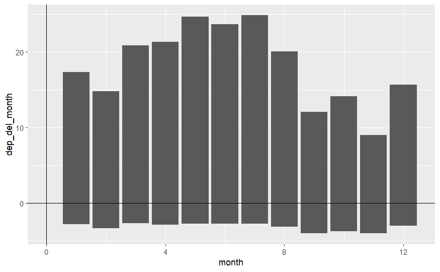

```r
dim(flights)
```

```
[1] 303748     19
```

```r
flights %>%
  unite(col = "flight_id", c("flight", "tailnum"), sep = " ") %>%
  group_by(flight_id)
```

| year | month | day | dep_time | sched_dep_time | dep_delay | arr_time | sched_arr_time | arr_delay | carrier | flight_id | origin | dest | air_time | distance | hour | minute | time_hour |
| --- | --- | --- | --- | --- | --- | --- | --- | --- | --- | --- | --- | --- | --- | --- | --- | --- | --- |
| 2017 | 10 | 1 | 27 | 2114 | 193 | 317 | 15 | 182 | UA | 1537 N54711 | EWR | MIA | 148 | 1085 | 21 | 14 | 2017-10-01 21:00:00 |
| 2017 | 10 | 1 | 519 | 525 | -6 | 741 | 759 | -18 | UA | 1161 N37287 | EWR | IAH | 183 | 1400 | 5 | 25 | 2017-10-01 05:00:00 |
| 2017 | 10 | 1 | 544 | 545 | -1 | 815 | 819 | -4 | B6 | 27 N547JB | EWR | MCO | 133 | 937 | 5 | 45 | 2017-10-01 05:00:00 |
| 2017 | 10 | 1 | 546 | 550 | -4 | 702 | 719 | -17 | UA | 761 N38446 | LGA | ORD | 108 | 733 | 5 | 50 | 2017-10-01 05:00:00 |
| 2017 | 10 | 1 | 552 | 600 | -8 | 846 | 850 | -4 | NK | 521 N675NK | EWR | FLL | 156 | 1065 | 6 | 0 | 2017-10-01 06:00:00 |
| 2017 | 10 | 1 | 553 | 600 | -7 | 852 | 858 | -6 | B6 | 23 N967JB | JFK | LAX | 326 | 2475 | 6 | 0 | 2017-10-01 06:00:00 |
| 2017 | 10 | 1 | 554 | 600 | -6 | 844 | 844 | 0 | AA | 129 N3GMAA | LGA | MCO | 139 | 950 | 6 | 0 | 2017-10-01 06:00:00 |
| 2017 | 10 | 1 | 555 | 607 | -12 | 831 | 853 | -22 | UA | 1465 N17229 | EWR | DFW | 187 | 1372 | 6 | 7 | 2017-10-01 06:00:00 |
| 2017 | 10 | 1 | 555 | 600 | -5 | 841 | 902 | -21 | AA | 1301 N3BMAA | EWR | MIA | 143 | 1085 | 6 | 0 | 2017-10-01 06:00:00 |
| 2017 | 10 | 1 | 556 | 600 | -4 | 802 | 815 | -13 | DL | 575 N932DL | EWR | ATL | 103 | 746 | 6 | 0 | 2017-10-01 06:00:00 |

[output cut: 990 more lines]

```r
?unite
```

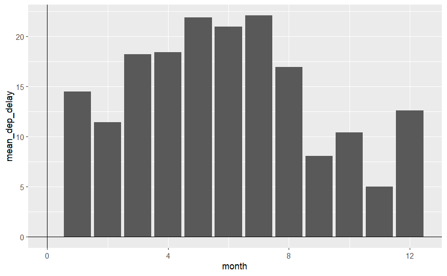

| origin |
| --- |
| EWR |
| LGA |
| JFK |

We have only three different ‘departure’ airports, which are also the same for which we have weather informations.

| origin |
| --- |
| EWR |
| JFK |
| LGA |

For these three we also have informations geographic information, since all these three belongs also to the ‘airports’ dataset.

| faa |
| --- |
| 0V4 |
| 19S |
| 23M |
| 2A5 |
| 2H0 |
| 2K7 |
| 3AU |
| 4A7 |
| 4U9 |
| 52A |

[output cut: 990 more lines]

| dest |
| --- |
| MIA |
| IAH |
| MCO |
| ORD |
| FLL |
| LAX |
| DFW |
| ATL |
| MDW |
| BUF |

[output cut: 99 more lines]

| dest | mean_delay |
| --- | --- |
| DSM | 53.82352941 |
| CHO | 44.13533835 |
| CAE | 37.33976834 |
| FWA | 34.85139319 |
| BHM | 33.11898734 |
| ILM | 31.22727273 |
| SMF | 29.46407767 |
| FNT | 28.55140187 |
| SBN | 27.45843230 |
| TYS | 26.60410959 |

[output cut: 99 more lines]

| faa | name |
| --- | --- |
| CAE | Columbia Metropolitan Airport |
| CHO | Charlottesville Albemarle Airport |
| DSM | Des Moines International Airport |